# Predict Bike Sharing Demand with AutoGluon Template

## Project: Predict Bike Sharing Demand with AutoGluon

This notebook is a template with each step that you need to complete for the project.

Please fill in your code where there are explicit `?` markers in the notebook. You are welcome to add more cells and code as you see fit.

Once you have completed all the code implementations, please export your notebook as a HTML file so the reviews can view your code. Make sure you have all outputs correctly outputted.

`File-> Export Notebook As... -> Export Notebook as HTML`

There is a writeup to complete as well after all code implememtation is done. Please answer all questions and attach the necessary tables and charts. You can complete the writeup in either markdown or PDF.

Completing the code template and writeup template will cover all of the rubric points for this project.

The rubric contains "Stand Out Suggestions" for enhancing the project beyond the minimum requirements. The stand out suggestions are optional. If you decide to pursue the "stand out suggestions", you can include the code in this notebook and also discuss the results in the writeup file.

## Step 1: Create an account with Kaggle

### Create Kaggle Account and download API key

Below is example of steps to get the API username and key. Each student will have their own username and key.

1. Open account settings.

2. Scroll down to API and click Create New API Token.

3. Open up `kaggle.json` and use the username and key.


## Step 2: Download the Kaggle dataset using the kaggle python library

### Open up Sagemaker Studio and use starter template

1. Notebook should be using a `ml.t3.medium` instance (2 vCPU + 4 GiB)
2. Notebook should be using kernal: `Python 3 (MXNet 1.8 Python 3.7 CPU Optimized)`

### Install packages

```python
!pip install -U pip
!pip install -U setuptools wheel
!pip install -U "mxnet<2.0.0" bokeh==2.0.1
!pip install autogluon --no-cache-dir
# Without --no-cache-dir, smaller aws instances may have trouble installing
```

[output not shown]

[output cut: 257 more lines]

[output not shown]

### Setup Kaggle API Key

```python
# create the .kaggle directory and an empty kaggle.json file
!mkdir -p /root/.kaggle
!touch /root/.kaggle/kaggle.json
!chmod 600 /root/.kaggle/kaggle.json
```

```python
# Fill in your user name and key from creating the kaggle account and API token file
import json
kaggle_username = "username"
kaggle_key = "token"

# Save API token the kaggle.json file
with open("/root/.kaggle/kaggle.json", "w") as f:
    f.write(json.dumps({"username": kaggle_username, "key": kaggle_key}))
```

### Download and explore dataset

### Go to the bike sharing demand competition and agree to the terms

```python
# Download the dataset, it will be in a .zip file so you'll need to unzip it as well.
!pip install kaggle
!kaggle competitions download -c bike-sharing-demand
# If you already downloaded it you can use the -o command to overwrite the file
!unzip -o bike-sharing-demand.zip
```

```
  Using cached kaggle-1.6.12-py3-none-any.whl
WARNING: Running pip as the 'root' user can result in broken permissions and conflicting behaviour with the system package manager. It is recommended to use a virtual environment instead: https://pip.pypa.io/warnings/venv
bike-sharing-demand.zip: Skipping, found more recently modified local copy (use --force to force download)
Archive:  bike-sharing-demand.zip
  inflating: sampleSubmission.csv
  inflating: test.csv
  inflating: train.csv
```

```python
import pandas as pd
import numpy as np
import matplotlib.pyplot as plt
%matplotlib inline
from autogluon.tabular import TabularPredictor
```

```python
# Create the train dataset in pandas by reading the csv
# Set the parsing of the datetime column so you can use some of the `dt` features in pandas later
train = pd.read_csv('train.csv',parse_dates=['datetime'])
train.head()
```

|  | datetime | season | holiday | workingday | weather | temp | atemp | humidity | windspeed | casual | registered | count |
| --- | --- | --- | --- | --- | --- | --- | --- | --- | --- | --- | --- | --- |
| 0 | 2011-01-01 00:00:00 | 1 | 0 | 0 | 1 | 9.84 | 14.395 | 81 | 0.0 | 3 | 13 | 16 |
| 1 | 2011-01-01 01:00:00 | 1 | 0 | 0 | 1 | 9.02 | 13.635 | 80 | 0.0 | 8 | 32 | 40 |
| 2 | 2011-01-01 02:00:00 | 1 | 0 | 0 | 1 | 9.02 | 13.635 | 80 | 0.0 | 5 | 27 | 32 |
| 3 | 2011-01-01 03:00:00 | 1 | 0 | 0 | 1 | 9.84 | 14.395 | 75 | 0.0 | 3 | 10 | 13 |
| 4 | 2011-01-01 04:00:00 | 1 | 0 | 0 | 1 | 9.84 | 14.395 | 75 | 0.0 | 0 | 1 | 1 |

```python
# Simple output of the train dataset to view some of the min/max/varition of the dataset features.
train.describe()
```

|  | datetime | season | holiday | workingday | weather | temp | atemp | humidity | windspeed | casual | registered | count |
| --- | --- | --- | --- | --- | --- | --- | --- | --- | --- | --- | --- | --- |
| count | 10886 | 10886.000000 | 10886.000000 | 10886.000000 | 10886.000000 | 10886.00000 | 10886.000000 | 10886.000000 | 10886.000000 | 10886.000000 | 10886.000000 | 10886.000000 |
| mean | 2011-12-27 05:56:22.399411968 | 2.506614 | 0.028569 | 0.680875 | 1.418427 | 20.23086 | 23.655084 | 61.886460 | 12.799395 | 36.021955 | 155.552177 | 191.574132 |
| min | 2011-01-01 00:00:00 | 1.000000 | 0.000000 | 0.000000 | 1.000000 | 0.82000 | 0.760000 | 0.000000 | 0.000000 | 0.000000 | 0.000000 | 1.000000 |
| 25% | 2011-07-02 07:15:00 | 2.000000 | 0.000000 | 0.000000 | 1.000000 | 13.94000 | 16.665000 | 47.000000 | 7.001500 | 4.000000 | 36.000000 | 42.000000 |
| 50% | 2012-01-01 20:30:00 | 3.000000 | 0.000000 | 1.000000 | 1.000000 | 20.50000 | 24.240000 | 62.000000 | 12.998000 | 17.000000 | 118.000000 | 145.000000 |
| 75% | 2012-07-01 12:45:00 | 4.000000 | 0.000000 | 1.000000 | 2.000000 | 26.24000 | 31.060000 | 77.000000 | 16.997900 | 49.000000 | 222.000000 | 284.000000 |
| max | 2012-12-19 23:00:00 | 4.000000 | 1.000000 | 1.000000 | 4.000000 | 41.00000 | 45.455000 | 100.000000 | 56.996900 | 367.000000 | 886.000000 | 977.000000 |
| std | NaN | 1.116174 | 0.166599 | 0.466159 | 0.633839 | 7.79159 | 8.474601 | 19.245033 | 8.164537 | 49.960477 | 151.039033 | 181.144454 |

```python
train.info()
```

```
<class 'pandas.core.frame.DataFrame'>
RangeIndex: 10886 entries, 0 to 10885
Data columns (total 12 columns):
 #   Column      Non-Null Count  Dtype
---  ------      --------------  -----
 0   datetime    10886 non-null  datetime64[ns]
 1   season      10886 non-null  int64
 2   holiday     10886 non-null  int64
 3   workingday  10886 non-null  int64
 4   weather     10886 non-null  int64
 5   temp        10886 non-null  float64
 6   atemp       10886 non-null  float64
 7   humidity    10886 non-null  int64
 8   windspeed   10886 non-null  float64
 9   casual      10886 non-null  int64
 10  registered  10886 non-null  int64
 11  count       10886 non-null  int64
dtypes: datetime64[ns](1), float64(3), int64(8)
memory usage: 1020.7 KB
```

```python
# Create the test pandas dataframe in pandas by reading the csv, remember to parse the datetime!
test = pd.read_csv('test.csv',parse_dates=['datetime'])
test.head()
```

|  | datetime | season | holiday | workingday | weather | temp | atemp | humidity | windspeed |
| --- | --- | --- | --- | --- | --- | --- | --- | --- | --- |
| 0 | 2011-01-20 00:00:00 | 1 | 0 | 1 | 1 | 10.66 | 11.365 | 56 | 26.0027 |
| 1 | 2011-01-20 01:00:00 | 1 | 0 | 1 | 1 | 10.66 | 13.635 | 56 | 0.0000 |
| 2 | 2011-01-20 02:00:00 | 1 | 0 | 1 | 1 | 10.66 | 13.635 | 56 | 0.0000 |
| 3 | 2011-01-20 03:00:00 | 1 | 0 | 1 | 1 | 10.66 | 12.880 | 56 | 11.0014 |
| 4 | 2011-01-20 04:00:00 | 1 | 0 | 1 | 1 | 10.66 | 12.880 | 56 | 11.0014 |

```python
# Same thing as train and test dataset
submission = pd.read_csv('sampleSubmission.csv',parse_dates=['datetime'])
submission.head()
```

|  | datetime | count |
| --- | --- | --- |
| 0 | 2011-01-20 00:00:00 | 0 |
| 1 | 2011-01-20 01:00:00 | 0 |
| 2 | 2011-01-20 02:00:00 | 0 |
| 3 | 2011-01-20 03:00:00 | 0 |
| 4 | 2011-01-20 04:00:00 | 0 |

```python
print('Columns which are not present in test:',list(col for col in train.columns if col not in test.columns))
```

```
Columns which are not present in test: ['casual', 'registered', 'count']
```

## Step 3: Train a model using AutoGluon’s Tabular Prediction

Requirements:

- We are prediting `count`, so it is the label we are setting.
- Ignore `casual` and `registered` columns as they are also not present in the test dataset.
- Use the `root_mean_squared_error` as the metric to use for evaluation.
- Set a time limit of 10 minutes (600 seconds).
- Use the preset `best_quality` to focus on creating the best model.

```python
predictor = TabularPredictor(label='count',eval_metric='root_mean_squared_error').fit(
    train_data=train.loc[:,~train.columns.isin(['casual','registered'])],time_limit=600,presets='best_quality'
)
```

```
No path specified. Models will be saved in: "AutogluonModels/ag-20240421_192702"
Presets specified: ['best_quality']
Setting dynamic_stacking from 'auto' to True. Reason: Enable dynamic_stacking when use_bag_holdout is disabled. (use_bag_holdout=False)
Stack configuration (auto_stack=True): num_stack_levels=1, num_bag_folds=8, num_bag_sets=1
Dynamic stacking is enabled (dynamic_stacking=True). AutoGluon will try to determine whether the input data is affected by stacked overfitting and enable or disable stacking as a consequence.
Detecting stacked overfitting by sub-fitting AutoGluon on the input data. That is, copies of AutoGluon will be sub-fit on subset(s) of the data. Then, the holdout validation data is used to detect stacked overfitting.
Sub-fit(s) time limit is: 600 seconds.
Starting holdout-based sub-fit for dynamic stacking. Context path is: AutogluonModels/ag-20240421_192702/ds_sub_fit/sub_fit_ho.
Running the sub-fit in a ray process to avoid memory leakage.
Spend 195 seconds for the sub-fit(s) during dynamic stacking.
Time left for full fit of AutoGluon: 405 seconds.
Starting full fit now with num_stack_levels 1.
Beginning AutoGluon training ... Time limit = 405s
AutoGluon will save models to "AutogluonModels/ag-20240421_192702"
=================== System Info ===================
AutoGluon Version:  1.1.0
Python Version:     3.8.18
Operating System:   Linux
Platform Machine:   x86_64
Platform Version:   #1 SMP Sat Mar 23 09:49:55 UTC 2024
CPU Count:          2
Memory Avail:       1.82 GB / 3.78 GB (48.0%)
Disk Space Avail:   8589934591.37 GB / 8589934592.00 GB (100.0%)
===================================================
Train Data Rows:    10886
Train Data Columns: 9
Label Column:       count
Problem Type:       regression
Preprocessing data ...
Using Feature Generators to preprocess the data ...
Fitting AutoMLPipelineFeatureGenerator...
	Available Memory:                    1858.09 MB
	Train Data (Original)  Memory Usage: 0.75 MB (0.0% of available memory)
	Inferring data type of each feature based on column values. Set feature_metadata_in to manually specify special dtypes of the features.
	Stage 1 Generators:
		Fitting AsTypeFeatureGenerator...
			Note: Converting 2 features to boolean dtype as they only contain 2 unique values.
	Stage 2 Generators:
		Fitting FillNaFeatureGenerator...
	Stage 3 Generators:
```

[output cut: 79 more lines]

```
	Fitting 8 child models (S1F1 - S1F8) | Fitting with ParallelLocalFoldFittingStrategy (2 workers, per: cpus=1, gpus=0, memory=0.62%)
	-55.0578	 = Validation score   (-root_mean_squared_error)
	29.67s	 = Training   runtime
	0.29s	 = Validation runtime
Fitting model: RandomForestMSE_BAG_L2 ... Training model for up to 27.03s of the 26.96s of remaining time.
	-53.4603	 = Validation score   (-root_mean_squared_error)
	45.73s	 = Training   runtime
	0.81s	 = Validation runtime
Fitting model: WeightedEnsemble_L3 ... Training model for up to 360.0s of the -25.05s of remaining time.
	Ensemble Weights: {'RandomForestMSE_BAG_L2': 0.708, 'LightGBM_BAG_L2': 0.25, 'LightGBMXT_BAG_L2': 0.042}
	-53.147	 = Validation score   (-root_mean_squared_error)
	0.07s	 = Training   runtime
	0.0s	 = Validation runtime
AutoGluon training complete, total runtime = 430.38s ... Best model: "WeightedEnsemble_L3"
TabularPredictor saved. To load, use: predictor = TabularPredictor.load("AutogluonModels/ag-20240421_192702")
```

### Review AutoGluon's training run with ranking of models that did the best.

```python
predictor.fit_summary()
```

```
*** Summary of fit() ***
Estimated performance of each model:
                     model   score_val              eval_metric  pred_time_val    fit_time  pred_time_val_marginal  fit_time_marginal  stack_level  can_infer  fit_order
0      WeightedEnsemble_L3  -53.146963  root_mean_squared_error      21.261850  386.538080                0.000959           0.069016            3       True         12
1   RandomForestMSE_BAG_L2  -53.460285  root_mean_squared_error      16.401969  296.059524                0.810363          45.732581            2       True         11
2          LightGBM_BAG_L2  -55.057808  root_mean_squared_error      15.885086  279.998146                0.293481          29.671203            2       True         10
3        LightGBMXT_BAG_L2  -60.555655  root_mean_squared_error      20.157047  311.065280                4.565441          60.738337            2       True          9
4    KNeighborsDist_BAG_L1  -84.125061  root_mean_squared_error       0.056049    0.046471                0.056049           0.046471            1       True          2
5      WeightedEnsemble_L2  -84.125061  root_mean_squared_error       0.057359    0.123414                0.001311           0.076942            2       True          8
6    KNeighborsUnif_BAG_L1 -101.546199  root_mean_squared_error       0.058116    0.062955                0.058116           0.062955            1       True          1
7   RandomForestMSE_BAG_L1 -116.548359  root_mean_squared_error       0.821373   17.694582                0.821373          17.694582            1       True          5
8     ExtraTreesMSE_BAG_L1 -124.600676  root_mean_squared_error       0.822318    8.953105                0.822318           8.953105            1       True          7
9          CatBoost_BAG_L1 -130.971079  root_mean_squared_error       0.131232  112.674234                0.131232         112.674234            1       True          6
10         LightGBM_BAG_L1 -131.054162  root_mean_squared_error       2.008122   34.752484                2.008122          34.752484            1       True          4
11       LightGBMXT_BAG_L1 -131.460909  root_mean_squared_error      11.694396   76.143111               11.694396          76.143111            1       True          3
Number of models trained: 12
Types of models trained:
{'StackerEnsembleModel_KNN', 'StackerEnsembleModel_RF', 'WeightedEnsembleModel', 'StackerEnsembleModel_CatBoost', 'StackerEnsembleModel_LGB', 'StackerEnsembleModel_XT'}
Bagging used: True  (with 8 folds)
Multi-layer stack-ensembling used: True  (with 3 levels)
Feature Metadata (Processed):
(raw dtype, special dtypes):
('float', [])                : 3 | ['temp', 'atemp', 'windspeed']
('int', [])                  : 3 | ['season', 'weather', 'humidity']
('int', ['bool'])            : 2 | ['holiday', 'workingday']
('int', ['datetime_as_int']) : 5 | ['datetime', 'datetime.year', 'datetime.month', 'datetime.day', 'datetime.dayofweek']
*** End of fit() summary ***
```

[output not shown]

[output cut: 102 more lines]

```
 11      11.694396   76.143111               11.694396          76.143111

     stack_level  can_infer  fit_order
 0             3       True         12
 1             2       True         11
 2             2       True         10
 3             2       True          9
 4             1       True          2
 5             2       True          8
 6             1       True          1
 7             1       True          5
 8             1       True          7
 9             1       True          6
 10            1       True          4
 11            1       True          3  }
```

### Create predictions from test dataset

```python
predictions = predictor.predict(test)
predictions.head()
```

```
0    23.249413
1    42.354645
2    45.558853
3    48.155968
4    50.971729
Name: count, dtype: float32
```

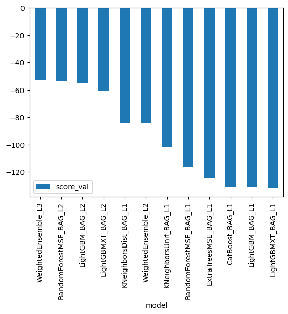

```python
predictor.leaderboard(silent=True).plot(kind='bar',x='model',y='score_val')
```

#### NOTE: Kaggle will reject the submission if we don't set everything to be > 0.

```python
# Describe the `predictions` series to see if there are any negative values
predictions.describe()
```

```
count    6493.000000
mean      100.557892
std        89.723206
min         3.099741
25%        20.319958
50%        64.309402
75%       168.780731
max       366.573761
Name: count, dtype: float64
```

```python
# How many negative values do we have?
print('Number of Negative values in Prediction:',predictions[predictions<0].count())
```

```
Number of Negative values in Prediction: 0
```

```python
# Set them to zero
predictions[predictions<0]=0
print('Number of Negative values in Prediction:',predictions[predictions<0].count())
```

```
Number of Negative values in Prediction: 0
```

### Set predictions to submission dataframe, save, and submit

```python
submission["count"] = predictions
submission.to_csv("submission.csv", index=False)
```

```python
!kaggle competitions submit -c bike-sharing-demand -f submission.csv -m "first raw submission"
```

#### View submission via the command line or in the web browser under the competition's page - `My Submissions`

```python
!kaggle competitions submissions -c bike-sharing-demand | tail -n +1 | head -n 6
```

[output not shown]

#### Initial score of `1.79978`

## Step 4: Exploratory Data Analysis and Creating an additional feature

- Any additional feature will do, but a great suggestion would be to separate out the datetime into hour, day, or month parts.

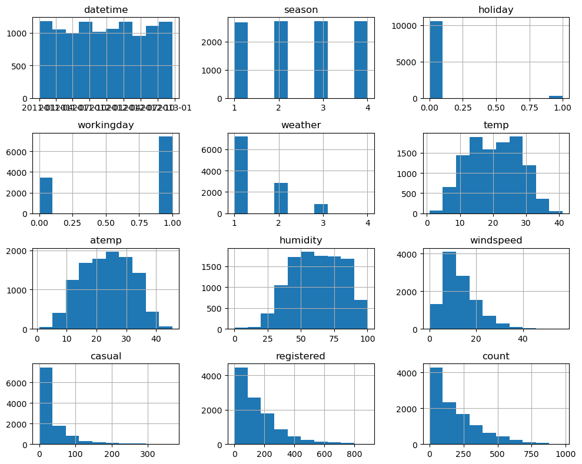

```python
# Create a histogram of all features to show the distribution of each one relative to the data. This is part of the exploritory data analysis
train.hist(figsize=(10,8))
plt.tight_layout()
plt.show()
```

```python
train.corr()
```

|  | datetime | season | holiday | workingday | weather | temp | atemp | humidity | windspeed | casual | registered | count |
| --- | --- | --- | --- | --- | --- | --- | --- | --- | --- | --- | --- | --- |
| datetime | 1.000000 | 0.480021 | 0.010988 | -0.003658 | -0.005048 | 0.180986 | 0.181823 | 0.032856 | -0.086888 | 0.172728 | 0.314879 | 0.310187 |
| season | 0.480021 | 1.000000 | 0.029368 | -0.008126 | 0.008879 | 0.258689 | 0.264744 | 0.190610 | -0.147121 | 0.096758 | 0.164011 | 0.163439 |
| holiday | 0.010988 | 0.029368 | 1.000000 | -0.250491 | -0.007074 | 0.000295 | -0.005215 | 0.001929 | 0.008409 | 0.043799 | -0.020956 | -0.005393 |
| workingday | -0.003658 | -0.008126 | -0.250491 | 1.000000 | 0.033772 | 0.029966 | 0.024660 | -0.010880 | 0.013373 | -0.319111 | 0.119460 | 0.011594 |
| weather | -0.005048 | 0.008879 | -0.007074 | 0.033772 | 1.000000 | -0.055035 | -0.055376 | 0.406244 | 0.007261 | -0.135918 | -0.109340 | -0.128655 |
| temp | 0.180986 | 0.258689 | 0.000295 | 0.029966 | -0.055035 | 1.000000 | 0.984948 | -0.064949 | -0.017852 | 0.467097 | 0.318571 | 0.394454 |
| atemp | 0.181823 | 0.264744 | -0.005215 | 0.024660 | -0.055376 | 0.984948 | 1.000000 | -0.043536 | -0.057473 | 0.462067 | 0.314635 | 0.389784 |
| humidity | 0.032856 | 0.190610 | 0.001929 | -0.010880 | 0.406244 | -0.064949 | -0.043536 | 1.000000 | -0.318607 | -0.348187 | -0.265458 | -0.317371 |
| windspeed | -0.086888 | -0.147121 | 0.008409 | 0.013373 | 0.007261 | -0.017852 | -0.057473 | -0.318607 | 1.000000 | 0.092276 | 0.091052 | 0.101369 |
| casual | 0.172728 | 0.096758 | 0.043799 | -0.319111 | -0.135918 | 0.467097 | 0.462067 | -0.348187 | 0.092276 | 1.000000 | 0.497250 | 0.690414 |
| registered | 0.314879 | 0.164011 | -0.020956 | 0.119460 | -0.109340 | 0.318571 | 0.314635 | -0.265458 | 0.091052 | 0.497250 | 1.000000 | 0.970948 |
| count | 0.310187 | 0.163439 | -0.005393 | 0.011594 | -0.128655 | 0.394454 | 0.389784 | -0.317371 | 0.101369 | 0.690414 | 0.970948 | 1.000000 |

Here I observed that co-relation between temp & atemp is 0.98 which is almost similar so I am going to drop atemp in both train and test data

```python
# create a new feature
# Creating new columns from datetime
train['hour'] = train['datetime'].dt.hour
test['hour'] = test['datetime'].dt.hour
train['day'] = train['datetime'].dt.dayofweek
test['day'] = test['datetime'].dt.dayofweek
train['month'] = train['datetime'].dt.month
test['month'] = test['datetime'].dt.month
```

```python
#dropping columns
columns_to_drop=['atemp','datetime']
train.drop(columns=columns_to_drop,inplace=True)
print(train.head())
test.drop(columns=columns_to_drop,inplace=True)
print(test.head())
```

```
   season  holiday  workingday  weather  temp  humidity  windspeed  casual  \
0       1        0           0        1  9.84        81        0.0       3
1       1        0           0        1  9.02        80        0.0       8
2       1        0           0        1  9.02        80        0.0       5
3       1        0           0        1  9.84        75        0.0       3
4       1        0           0        1  9.84        75        0.0       0

   registered  count  hour  day  month
0          13     16     0    5      1
1          32     40     1    5      1
2          27     32     2    5      1
3          10     13     3    5      1
4           1      1     4    5      1
   season  holiday  workingday  weather   temp  humidity  windspeed  hour  \
0       1        0           1        1  10.66        56    26.0027     0
1       1        0           1        1  10.66        56     0.0000     1
2       1        0           1        1  10.66        56     0.0000     2
3       1        0           1        1  10.66        56    11.0014     3
4       1        0           1        1  10.66        56    11.0014     4

   day  month
0    3      1
1    3      1
2    3      1
3    3      1
4    3      1
```

```python
#dropping cloumns from train data as there are no corresponding columns in test data
train.drop(columns=['casual','registered'],inplace=True)
print(train.head())
```

```
   season  holiday  workingday  weather  temp  humidity  windspeed  count  \
0       1        0           0        1  9.84        81        0.0     16
1       1        0           0        1  9.02        80        0.0     40
2       1        0           0        1  9.02        80        0.0     32
3       1        0           0        1  9.84        75        0.0     13
4       1        0           0        1  9.84        75        0.0      1

   hour  day  month
0     0    5      1
1     1    5      1
2     2    5      1
3     3    5      1
4     4    5      1
```

## Make category types for these so models know they are not just numbers

- AutoGluon originally sees these as ints, but in reality they are int representations of a category.
- Setting the dtype to category will classify these as categories in AutoGluon.

```python
train["season"] = train["season"].astype('category')
train["weather"] = train["weather"].astype('category')
test["season"] = test["season"].astype('category')
test["weather"] = test["weather"].astype('category')
```

```python
# View are new feature
train.head()
```

|  | season | holiday | workingday | weather | temp | humidity | windspeed | count | hour | day | month |
| --- | --- | --- | --- | --- | --- | --- | --- | --- | --- | --- | --- |
| 0 | 1 | 0 | 0 | 1 | 9.84 | 81 | 0.0 | 16 | 0 | 5 | 1 |
| 1 | 1 | 0 | 0 | 1 | 9.02 | 80 | 0.0 | 40 | 1 | 5 | 1 |
| 2 | 1 | 0 | 0 | 1 | 9.02 | 80 | 0.0 | 32 | 2 | 5 | 1 |
| 3 | 1 | 0 | 0 | 1 | 9.84 | 75 | 0.0 | 13 | 3 | 5 | 1 |
| 4 | 1 | 0 | 0 | 1 | 9.84 | 75 | 0.0 | 1 | 4 | 5 | 1 |

```python
train.info()
```

```
<class 'pandas.core.frame.DataFrame'>
RangeIndex: 10886 entries, 0 to 10885
Data columns (total 11 columns):
 #   Column      Non-Null Count  Dtype
---  ------      --------------  -----
 0   season      10886 non-null  category
 1   holiday     10886 non-null  int64
 2   workingday  10886 non-null  int64
 3   weather     10886 non-null  category
 4   temp        10886 non-null  float64
 5   humidity    10886 non-null  int64
 6   windspeed   10886 non-null  float64
 7   count       10886 non-null  int64
 8   hour        10886 non-null  int32
 9   day         10886 non-null  int32
 10  month       10886 non-null  int32
dtypes: category(2), float64(2), int32(3), int64(4)
memory usage: 659.6 KB
```

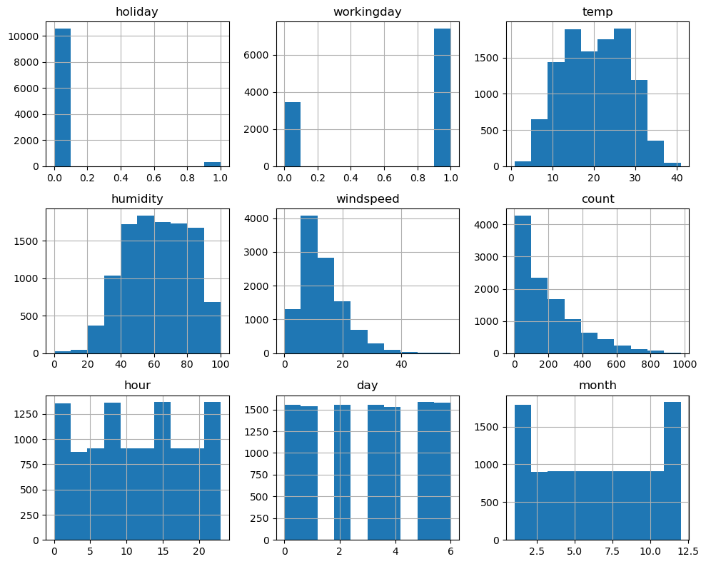

```python
# View histogram of all features again now with the hour feature
train.hist(figsize=(10,8))
plt.tight_layout()
plt.show()
```

```python
train.corr()
```

|  | season | holiday | workingday | weather | temp | humidity | windspeed | count | hour | day | month |
| --- | --- | --- | --- | --- | --- | --- | --- | --- | --- | --- | --- |
| season | 1.000000 | 0.029368 | -0.008126 | 0.008879 | 0.258689 | 0.190610 | -0.147121 | 0.163439 | -0.006546 | -0.010553 | 0.971524 |
| holiday | 0.029368 | 1.000000 | -0.250491 | -0.007074 | 0.000295 | 0.001929 | 0.008409 | -0.005393 | -0.000354 | -0.191832 | 0.001731 |
| workingday | -0.008126 | -0.250491 | 1.000000 | 0.033772 | 0.029966 | -0.010880 | 0.013373 | 0.011594 | 0.002780 | -0.704267 | -0.003394 |
| weather | 0.008879 | -0.007074 | 0.033772 | 1.000000 | -0.055035 | 0.406244 | 0.007261 | -0.128655 | -0.022740 | -0.047692 | 0.012144 |
| temp | 0.258689 | 0.000295 | 0.029966 | -0.055035 | 1.000000 | -0.064949 | -0.017852 | 0.394454 | 0.145430 | -0.038466 | 0.257589 |
| humidity | 0.190610 | 0.001929 | -0.010880 | 0.406244 | -0.064949 | 1.000000 | -0.318607 | -0.317371 | -0.278011 | -0.026507 | 0.204537 |
| windspeed | -0.147121 | 0.008409 | 0.013373 | 0.007261 | -0.017852 | -0.318607 | 1.000000 | 0.101369 | 0.146631 | -0.024804 | -0.150192 |
| count | 0.163439 | -0.005393 | 0.011594 | -0.128655 | 0.394454 | -0.317371 | 0.101369 | 1.000000 | 0.400601 | -0.002283 | 0.166862 |
| hour | -0.006546 | -0.000354 | 0.002780 | -0.022740 | 0.145430 | -0.278011 | 0.146631 | 0.400601 | 1.000000 | -0.002925 | -0.006818 |
| day | -0.010553 | -0.191832 | -0.704267 | -0.047692 | -0.038466 | -0.026507 | -0.024804 | -0.002283 | -0.002925 | 1.000000 | -0.002266 |
| month | 0.971524 | 0.001731 | -0.003394 | 0.012144 | 0.257589 | 0.204537 | -0.150192 | 0.166862 | -0.006818 | -0.002266 | 1.000000 |

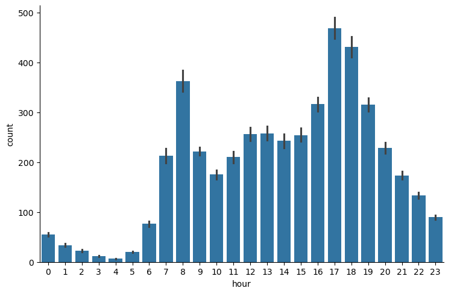

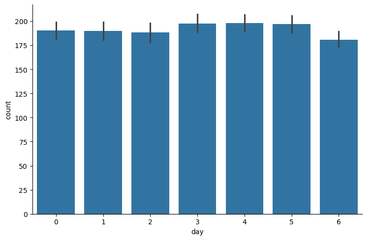

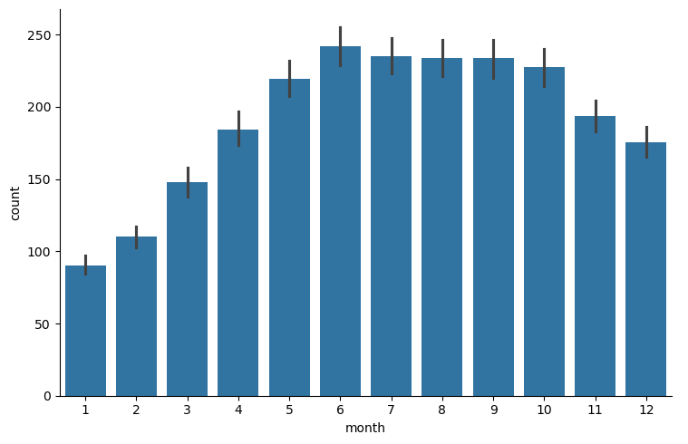

```python
import seaborn as sns
sns.catplot(x="hour",y="count",data=train,kind='bar',height=5,aspect=1.5)
sns.catplot(x="day",y="count",data=train,kind='bar',height=5,aspect=1.5)
sns.catplot(x="month",y="count",data=train,kind='bar',height=5,aspect=1.5)
plt.tight_layout()
plt.show()
```

We can observe the count is increasing from 6AM and then decreasing after 8AM and then maintaining a similar count in between in 9AM - 3PM We can observe a peak count in between 4PM-7PM(inclusive) and then decreasing From month 5th to 10th count is high compared to other months Each day the count is almost similar.So I am thinking to drop the column day

```python
train.drop(columns='day',inplace=True)
train.head()
```

|  | season | holiday | workingday | weather | temp | humidity | windspeed | count | hour | month |
| --- | --- | --- | --- | --- | --- | --- | --- | --- | --- | --- |
| 0 | 1 | 0 | 0 | 1 | 9.84 | 81 | 0.0 | 16 | 0 | 1 |
| 1 | 1 | 0 | 0 | 1 | 9.02 | 80 | 0.0 | 40 | 1 | 1 |
| 2 | 1 | 0 | 0 | 1 | 9.02 | 80 | 0.0 | 32 | 2 | 1 |
| 3 | 1 | 0 | 0 | 1 | 9.84 | 75 | 0.0 | 13 | 3 | 1 |
| 4 | 1 | 0 | 0 | 1 | 9.84 | 75 | 0.0 | 1 | 4 | 1 |

```python
test.drop(columns='day',inplace=True)
test.head()
```

|  | season | holiday | workingday | weather | temp | humidity | windspeed | hour | month |
| --- | --- | --- | --- | --- | --- | --- | --- | --- | --- |
| 0 | 1 | 0 | 1 | 1 | 10.66 | 56 | 26.0027 | 0 | 1 |
| 1 | 1 | 0 | 1 | 1 | 10.66 | 56 | 0.0000 | 1 | 1 |
| 2 | 1 | 0 | 1 | 1 | 10.66 | 56 | 0.0000 | 2 | 1 |
| 3 | 1 | 0 | 1 | 1 | 10.66 | 56 | 11.0014 | 3 | 1 |
| 4 | 1 | 0 | 1 | 1 | 10.66 | 56 | 11.0014 | 4 | 1 |

## Step 5: Rerun the model with the same settings as before, just with more features

```python
predictor_new_features = TabularPredictor(label='count',eval_metric='root_mean_squared_error').fit(
    train_data=train,time_limit=600,presets='best_quality'
)
```

```
No path specified. Models will be saved in: "AutogluonModels/ag-20240427_064515"
Presets specified: ['best_quality']
Setting dynamic_stacking from 'auto' to True. Reason: Enable dynamic_stacking when use_bag_holdout is disabled. (use_bag_holdout=False)
Stack configuration (auto_stack=True): num_stack_levels=1, num_bag_folds=8, num_bag_sets=1
Dynamic stacking is enabled (dynamic_stacking=True). AutoGluon will try to determine whether the input data is affected by stacked overfitting and enable or disable stacking as a consequence.
Detecting stacked overfitting by sub-fitting AutoGluon on the input data. That is, copies of AutoGluon will be sub-fit on subset(s) of the data. Then, the holdout validation data is used to detect stacked overfitting.
Sub-fit(s) time limit is: 600 seconds.
Starting holdout-based sub-fit for dynamic stacking. Context path is: AutogluonModels/ag-20240427_064515/ds_sub_fit/sub_fit_ho.
Running the sub-fit in a ray process to avoid memory leakage.
Spend 180 seconds for the sub-fit(s) during dynamic stacking.
Time left for full fit of AutoGluon: 420 seconds.
Starting full fit now with num_stack_levels 0.
Beginning AutoGluon training ... Time limit = 420s
AutoGluon will save models to "AutogluonModels/ag-20240427_064515"
=================== System Info ===================
AutoGluon Version:  1.1.0
Python Version:     3.8.18
Operating System:   Linux
Platform Machine:   x86_64
Platform Version:   #1 SMP Sat Mar 23 09:49:55 UTC 2024
CPU Count:          2
Memory Avail:       1.94 GB / 3.78 GB (51.2%)
Disk Space Avail:   8589934590.37 GB / 8589934592.00 GB (100.0%)
===================================================
Train Data Rows:    10886
Train Data Columns: 9
Label Column:       count
Problem Type:       regression
Preprocessing data ...
Using Feature Generators to preprocess the data ...
Fitting AutoMLPipelineFeatureGenerator...
	Available Memory:                    1981.97 MB
	Train Data (Original)  Memory Usage: 0.52 MB (0.0% of available memory)
	Inferring data type of each feature based on column values. Set feature_metadata_in to manually specify special dtypes of the features.
	Stage 1 Generators:
		Fitting AsTypeFeatureGenerator...
			Note: Converting 2 features to boolean dtype as they only contain 2 unique values.
	Stage 2 Generators:
		Fitting FillNaFeatureGenerator...
	Stage 3 Generators:
```

[output cut: 64 more lines]

```
	-66.1569	 = Validation score   (-root_mean_squared_error)
	5.25s	 = Training   runtime
	0.57s	 = Validation runtime
Fitting model: NeuralNetFastAI_BAG_L1 ... Training model for up to 36.44s of the 36.41s of remaining time.
	Fitting 8 child models (S1F1 - S1F8) | Fitting with ParallelLocalFoldFittingStrategy (2 workers, per: cpus=1, gpus=0, memory=0.21%)
	-89.1539	 = Validation score   (-root_mean_squared_error)
	55.07s	 = Training   runtime
	0.48s	 = Validation runtime
Fitting model: WeightedEnsemble_L2 ... Training model for up to 360.0s of the -23.68s of remaining time.
	Ensemble Weights: {'LightGBMXT_BAG_L1': 0.35, 'LightGBM_BAG_L1': 0.3, 'CatBoost_BAG_L1': 0.3, 'RandomForestMSE_BAG_L1': 0.05}
	-60.3797	 = Validation score   (-root_mean_squared_error)
	0.03s	 = Training   runtime
	0.0s	 = Validation runtime
AutoGluon training complete, total runtime = 443.96s ... Best model: "WeightedEnsemble_L2"
TabularPredictor saved. To load, use: predictor = TabularPredictor.load("AutogluonModels/ag-20240427_064515")
```

```python
predictor_new_features.fit_summary()
```

```
*** Summary of fit() ***
Estimated performance of each model:
                    model   score_val              eval_metric  pred_time_val    fit_time  pred_time_val_marginal  fit_time_marginal  stack_level  can_infer  fit_order
0     WeightedEnsemble_L2  -60.379721  root_mean_squared_error      19.777910  358.371615                0.000975           0.034939            2       True          9
1         CatBoost_BAG_L1  -61.874702  root_mean_squared_error       0.209759  241.828139                0.209759         241.828139            1       True          6
2         LightGBM_BAG_L1  -61.921315  root_mean_squared_error       2.458833   31.470046                2.458833          31.470046            1       True          4
3       LightGBMXT_BAG_L1  -62.020443  root_mean_squared_error      16.372542   74.480259               16.372542          74.480259            1       True          3
4    ExtraTreesMSE_BAG_L1  -66.156867  root_mean_squared_error       0.565518    5.247020                0.565518           5.247020            1       True          7
5  RandomForestMSE_BAG_L1  -67.303777  root_mean_squared_error       0.735801   10.558231                0.735801          10.558231            1       True          5
6  NeuralNetFastAI_BAG_L1  -89.153855  root_mean_squared_error       0.477485   55.066587                0.477485          55.066587            1       True          8
7   KNeighborsDist_BAG_L1 -119.021383  root_mean_squared_error       0.123812    0.053222                0.123812           0.053222            1       True          2
8   KNeighborsUnif_BAG_L1 -120.528013  root_mean_squared_error       0.147996    0.037640                0.147996           0.037640            1       True          1
Number of models trained: 9
Types of models trained:
{'StackerEnsembleModel_LGB', 'StackerEnsembleModel_CatBoost', 'WeightedEnsembleModel', 'StackerEnsembleModel_XT', 'StackerEnsembleModel_KNN', 'StackerEnsembleModel_NNFastAiTabular', 'StackerEnsembleModel_RF'}
Bagging used: True  (with 8 folds)
Multi-layer stack-ensembling used: False
Feature Metadata (Processed):
(raw dtype, special dtypes):
('category', [])  : 2 | ['season', 'weather']
('float', [])     : 2 | ['temp', 'windspeed']
('int', [])       : 3 | ['humidity', 'hour', 'month']
('int', ['bool']) : 2 | ['holiday', 'workingday']
*** End of fit() summary ***
```

[output not shown]

[output cut: 65 more lines]

```
 5   10.558231                0.735801          10.558231            1
 6   55.066587                0.477485          55.066587            1
 7    0.053222                0.123812           0.053222            1
 8    0.037640                0.147996           0.037640            1

    can_infer  fit_order
 0       True          9
 1       True          6
 2       True          4
 3       True          3
 4       True          7
 5       True          5
 6       True          8
 7       True          2
 8       True          1  }
```

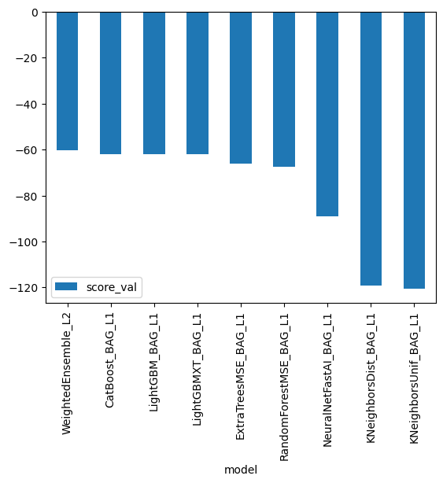

```python
predictor_new_features.leaderboard(silent=True).plot(kind='bar',x='model',y='score_val')
```

```python
predictions_new_features = predictor_new_features.predict(test)
predictions_new_features.head()
```

```
0    27.563478
1     2.617415
2    -0.916615
3    -0.309014
4    -0.572330
Name: count, dtype: float32
```

```python
predictions_new_features.describe()
```

```
count    6493.000000
mean      187.657669
std       166.159561
min       -32.696609
25%        45.145809
50%       149.813171
75%       278.792542
max       836.316162
Name: count, dtype: float64
```

```python
# How many negative values do we have?
print('Number of Negative values in Prediction:',predictions_new_features[predictions_new_features<0].count())
```

```
Number of Negative values in Prediction: 227
```

```python
# Remember to set all negative values to zero
predictions_new_features[predictions_new_features<0]=0
print('Number of Negative values in Prediction:',predictions_new_features[predictions_new_features<0].count())
```

```
Number of Negative values in Prediction: 0
```

```python
submission_new_features = pd.read_csv('sampleSubmission.csv',parse_dates=['datetime'])
submission_new_features.head()
```

|  | datetime | count |
| --- | --- | --- |
| 0 | 2011-01-20 00:00:00 | 0 |
| 1 | 2011-01-20 01:00:00 | 0 |
| 2 | 2011-01-20 02:00:00 | 0 |
| 3 | 2011-01-20 03:00:00 | 0 |
| 4 | 2011-01-20 04:00:00 | 0 |

```python
# Same submitting predictions
submission_new_features["count"] = predictions_new_features
submission_new_features.to_csv("submission_new_features.csv", index=False)
```

```python
!kaggle competitions submit -c bike-sharing-demand -f submission_new_features.csv -m "new features"
```

```python
!kaggle competitions submissions -c bike-sharing-demand | tail -n +1 | head -n 6
```

#### New Score of `0.70549`

## Step 5.1:Test_New_features

Here I am removing month column as there are so much similar distributions and to check the model performance if month column is not there

```python
new_train=train.drop(columns='month')
new_train.head()
```

|  | season | holiday | workingday | weather | temp | humidity | windspeed | count | hour |
| --- | --- | --- | --- | --- | --- | --- | --- | --- | --- |
| 0 | 1 | 0 | 0 | 1 | 9.84 | 81 | 0.0 | 16 | 0 |
| 1 | 1 | 0 | 0 | 1 | 9.02 | 80 | 0.0 | 40 | 1 |
| 2 | 1 | 0 | 0 | 1 | 9.02 | 80 | 0.0 | 32 | 2 |
| 3 | 1 | 0 | 0 | 1 | 9.84 | 75 | 0.0 | 13 | 3 |
| 4 | 1 | 0 | 0 | 1 | 9.84 | 75 | 0.0 | 1 | 4 |

```python
new_test=test.drop(columns='month')
new_test.head()
```

|  | season | holiday | workingday | weather | temp | humidity | windspeed | hour |
| --- | --- | --- | --- | --- | --- | --- | --- | --- |
| 0 | 1 | 0 | 1 | 1 | 10.66 | 56 | 26.0027 | 0 |
| 1 | 1 | 0 | 1 | 1 | 10.66 | 56 | 0.0000 | 1 |
| 2 | 1 | 0 | 1 | 1 | 10.66 | 56 | 0.0000 | 2 |
| 3 | 1 | 0 | 1 | 1 | 10.66 | 56 | 11.0014 | 3 |
| 4 | 1 | 0 | 1 | 1 | 10.66 | 56 | 11.0014 | 4 |

```python
predictor_new_features1 = TabularPredictor(label='count',eval_metric='root_mean_squared_error').fit(
    train_data=new_train,time_limit=600,presets='best_quality'
)
```

[output not shown]

[output cut: 90 more lines]

```
	-64.8824	 = Validation score   (-root_mean_squared_error)
	33.99s	 = Training   runtime
	0.72s	 = Validation runtime
Fitting model: CatBoost_BAG_L2 ... Training model for up to 35.89s of the 35.84s of remaining time.
	Fitting 8 child models (S1F1 - S1F8) | Fitting with ParallelLocalFoldFittingStrategy (2 workers, per: cpus=1, gpus=0, memory=0.58%)
	-64.2146	 = Validation score   (-root_mean_squared_error)
	39.85s	 = Training   runtime
	0.18s	 = Validation runtime
Fitting model: WeightedEnsemble_L3 ... Training model for up to 360.0s of the -9.78s of remaining time.
	Ensemble Weights: {'CatBoost_BAG_L2': 0.353, 'LightGBMXT_BAG_L1': 0.235, 'RandomForestMSE_BAG_L2': 0.235, 'CatBoost_BAG_L1': 0.118, 'LightGBM_BAG_L1': 0.059}
	-63.7504	 = Validation score   (-root_mean_squared_error)
	0.06s	 = Training   runtime
	0.0s	 = Validation runtime
AutoGluon training complete, total runtime = 443.1s ... Best model: "WeightedEnsemble_L3"
TabularPredictor saved. To load, use: predictor = TabularPredictor.load("AutogluonModels/ag-20240427_072126")
```

```python
predictor_new_features1.fit_summary()
```

```
*** Summary of fit() ***
Estimated performance of each model:
                     model   score_val              eval_metric  pred_time_val    fit_time  pred_time_val_marginal  fit_time_marginal  stack_level  can_infer  fit_order
0      WeightedEnsemble_L3  -63.750353  root_mean_squared_error      11.878604  368.045594                0.000946           0.057232            3       True         14
1      WeightedEnsemble_L2  -64.135954  root_mean_squared_error       9.681239  248.936165                0.001138           0.028800            2       True          9
2          CatBoost_BAG_L2  -64.214621  root_mean_squared_error      11.154648  333.993602                0.184041          39.853077            2       True         13
3   RandomForestMSE_BAG_L2  -64.882383  root_mean_squared_error      11.693617  328.135285                0.723010          33.994760            2       True         12
4          LightGBM_BAG_L2  -65.089429  root_mean_squared_error      11.061735  312.652954                0.091128          18.512429            2       True         11
5        LightGBMXT_BAG_L1  -65.136555  root_mean_squared_error       6.884407   48.957228                6.884407          48.957228            1       True          3
6        LightGBMXT_BAG_L2  -65.140698  root_mean_squared_error      11.190277  312.546651                0.219670          18.406126            2       True         10
7          CatBoost_BAG_L1  -65.658449  root_mean_squared_error       0.156156  166.205038                0.156156         166.205038            1       True          6
8          LightGBM_BAG_L1  -66.051752  root_mean_squared_error       2.055872   25.418944                2.055872          25.418944            1       True          4
9     ExtraTreesMSE_BAG_L1  -69.069267  root_mean_squared_error       0.651658    4.927043                0.651658           4.927043            1       True          7
10  RandomForestMSE_BAG_L1  -69.793084  root_mean_squared_error       0.583666    8.326155                0.583666           8.326155            1       True          5
11  NeuralNetFastAI_BAG_L1 -120.620670  root_mean_squared_error       0.432309   40.237861                0.432309          40.237861            1       True          8
12   KNeighborsUnif_BAG_L1 -123.122408  root_mean_squared_error       0.108856    0.041751                0.108856           0.041751            1       True          1
13   KNeighborsDist_BAG_L1 -124.470116  root_mean_squared_error       0.097683    0.026504                0.097683           0.026504            1       True          2
Number of models trained: 14
Types of models trained:
{'StackerEnsembleModel_LGB', 'StackerEnsembleModel_CatBoost', 'WeightedEnsembleModel', 'StackerEnsembleModel_XT', 'StackerEnsembleModel_KNN', 'StackerEnsembleModel_NNFastAiTabular', 'StackerEnsembleModel_RF'}
Bagging used: True  (with 8 folds)
Multi-layer stack-ensembling used: True  (with 3 levels)
Feature Metadata (Processed):
(raw dtype, special dtypes):
('category', [])  : 2 | ['season', 'weather']
('float', [])     : 2 | ['temp', 'windspeed']
('int', [])       : 2 | ['humidity', 'hour']
('int', ['bool']) : 2 | ['holiday', 'workingday']
*** End of fit() summary ***
```

[output not shown]

[output cut: 126 more lines]

```
     stack_level  can_infer  fit_order
 0             3       True         14
 1             2       True          9
 2             2       True         13
 3             2       True         12
 4             2       True         11
 5             1       True          3
 6             2       True         10
 7             1       True          6
 8             1       True          4
 9             1       True          7
 10            1       True          5
 11            1       True          8
 12            1       True          1
 13            1       True          2  }
```

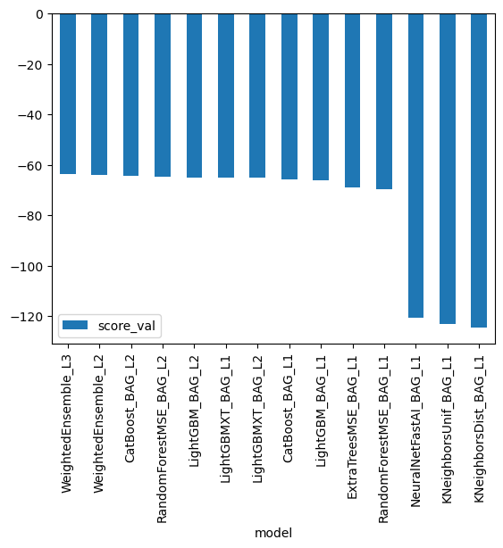

```python
predictor_new_features1.leaderboard(silent=True).plot(kind='bar',x='model',y='score_val')
```

```python
predictions_new_features1 = predictor_new_features1.predict(new_test)
predictions_new_features1.head()
```

```
0    17.414507
1     6.034058
2     4.679436
3     3.502137
4     4.019640
Name: count, dtype: float32
```

```python
# How many negative values do we have?
print('Number of Negative values in Prediction:',predictions_new_features1[predictions_new_features1<0].count())
```

```
Number of Negative values in Prediction: 39
```

```python
# Remember to set all negative values to zero
predictions_new_features1[predictions_new_features1<0]=0
print('Number of Negative values in Prediction:',predictions_new_features1[predictions_new_features1<0].count())
```

```
Number of Negative values in Prediction: 0
```

```python
submission_new_features1 = pd.read_csv('sampleSubmission.csv',parse_dates=['datetime'])
submission_new_features1.head()
```

|  | datetime | count |
| --- | --- | --- |
| 0 | 2011-01-20 00:00:00 | 0 |
| 1 | 2011-01-20 01:00:00 | 0 |
| 2 | 2011-01-20 02:00:00 | 0 |
| 3 | 2011-01-20 03:00:00 | 0 |
| 4 | 2011-01-20 04:00:00 | 0 |

```python
# Same submitting predictions
submission_new_features1["count"] = predictions_new_features1
submission_new_features1.to_csv("submission_new_features1.csv", index=False)
```

```python
!kaggle competitions submit -c bike-sharing-demand -f submission_new_features1.csv -m "new features1"
```

```python
!kaggle competitions submissions -c bike-sharing-demand | tail -n +1 | head -n 6
```

#### New Score of `0.52283`

## Step 5.2:Test_New_features

Here I am adding year column along with time and month

```python
# create a new feature
# Creating new columns from datetime
train['hour'] = train['datetime'].dt.hour
test['hour'] = test['datetime'].dt.hour
train['day'] = train['datetime'].dt.year
test['day'] = test['datetime'].dt.year
train['month'] = train['datetime'].dt.month
test['month'] = test['datetime'].dt.month
```

Small mistake Here i named year as column day :)

```python
train.drop(columns=['atemp','datetime','casual','registered'],inplace=True)
print(train.head())
test.drop(columns=['atemp','datetime'],inplace=True)
print(test.head())
```

```
   season  holiday  workingday  weather  temp  humidity  windspeed  count  \
0       1        0           0        1  9.84        81        0.0     16
1       1        0           0        1  9.02        80        0.0     40
2       1        0           0        1  9.02        80        0.0     32
3       1        0           0        1  9.84        75        0.0     13
4       1        0           0        1  9.84        75        0.0      1

   hour   day  month
0     0  2011      1
1     1  2011      1
2     2  2011      1
3     3  2011      1
4     4  2011      1
   season  holiday  workingday  weather   temp  humidity  windspeed  hour  \
0       1        0           1        1  10.66        56    26.0027     0
1       1        0           1        1  10.66        56     0.0000     1
2       1        0           1        1  10.66        56     0.0000     2
3       1        0           1        1  10.66        56    11.0014     3
4       1        0           1        1  10.66        56    11.0014     4

    day  month
0  2011      1
1  2011      1
2  2011      1
3  2011      1
4  2011      1
```

```python
predictor_new_features2 = TabularPredictor(label='count',eval_metric='root_mean_squared_error').fit(
    train_data=train,time_limit=600,presets='best_quality'
)
```

[output not shown]

[output cut: 86 more lines]

```
	-39.6019	 = Validation score   (-root_mean_squared_error)
	36.88s	 = Training   runtime
	0.85s	 = Validation runtime
Fitting model: CatBoost_BAG_L2 ... Training model for up to 27.22s of the 27.17s of remaining time.
	Fitting 8 child models (S1F1 - S1F8) | Fitting with ParallelLocalFoldFittingStrategy (2 workers, per: cpus=1, gpus=0, memory=0.74%)
	-38.4594	 = Validation score   (-root_mean_squared_error)
	29.79s	 = Training   runtime
	0.07s	 = Validation runtime
Fitting model: WeightedEnsemble_L3 ... Training model for up to 360.0s of the -8.21s of remaining time.
	Ensemble Weights: {'CatBoost_BAG_L1': 0.261, 'CatBoost_BAG_L2': 0.261, 'LightGBMXT_BAG_L1': 0.174, 'LightGBM_BAG_L2': 0.174, 'ExtraTreesMSE_BAG_L1': 0.087, 'LightGBM_BAG_L1': 0.043}
	-38.0737	 = Validation score   (-root_mean_squared_error)
	0.07s	 = Training   runtime
	0.0s	 = Validation runtime
AutoGluon training complete, total runtime = 438.54s ... Best model: "WeightedEnsemble_L3"
TabularPredictor saved. To load, use: predictor = TabularPredictor.load("AutogluonModels/ag-20240427_074833")
```

```python
predictor_new_features2.fit_summary()
```

```
*** Summary of fit() ***
Estimated performance of each model:
                     model   score_val              eval_metric  pred_time_val    fit_time  pred_time_val_marginal  fit_time_marginal  stack_level  can_infer  fit_order
0      WeightedEnsemble_L3  -38.073726  root_mean_squared_error      17.880780  342.984619                0.000978           0.066110            3       True         14
1      WeightedEnsemble_L2  -38.201720  root_mean_squared_error      17.095869  252.506495                0.001055           0.037074            2       True          9
2          CatBoost_BAG_L2  -38.459413  root_mean_squared_error      17.794568  324.046323                0.068977          29.790590            2       True         13
3          LightGBM_BAG_L2  -38.703128  root_mean_squared_error      17.810825  313.127919                0.085234          18.872187            2       True         11
4        LightGBMXT_BAG_L2  -39.013937  root_mean_squared_error      17.965743  314.198606                0.240152          19.942874            2       True         10
5          CatBoost_BAG_L1  -39.113819  root_mean_squared_error       0.084594  140.974781                0.084594         140.974781            1       True          6
6   RandomForestMSE_BAG_L2  -39.601935  root_mean_squared_error      18.573820  331.131077                0.848229          36.875345            2       True         12
7        LightGBMXT_BAG_L1  -39.961797  root_mean_squared_error      13.915206   70.102841               13.915206          70.102841            1       True          3
8          LightGBM_BAG_L1  -39.972535  root_mean_squared_error       1.840251   25.673875                1.840251          25.673875            1       True          4
9     ExtraTreesMSE_BAG_L1  -41.989149  root_mean_squared_error       0.671974    6.166846                0.671974           6.166846            1       True          7
10  RandomForestMSE_BAG_L1  -43.451837  root_mean_squared_error       0.582788    9.551078                0.582788           9.551078            1       True          5
11  NeuralNetFastAI_BAG_L1 -109.249513  root_mean_squared_error       0.290024   41.662178                0.290024          41.662178            1       True          8
12   KNeighborsDist_BAG_L1 -118.291932  root_mean_squared_error       0.181043    0.046903                0.181043           0.046903            1       True          2
13   KNeighborsUnif_BAG_L1 -120.180680  root_mean_squared_error       0.159710    0.077230                0.159710           0.077230            1       True          1
Number of models trained: 14
Types of models trained:
{'StackerEnsembleModel_LGB', 'StackerEnsembleModel_CatBoost', 'WeightedEnsembleModel', 'StackerEnsembleModel_XT', 'StackerEnsembleModel_KNN', 'StackerEnsembleModel_NNFastAiTabular', 'StackerEnsembleModel_RF'}
Bagging used: True  (with 8 folds)
Multi-layer stack-ensembling used: True  (with 3 levels)
Feature Metadata (Processed):
(raw dtype, special dtypes):
('float', [])     : 2 | ['temp', 'windspeed']
('int', [])       : 5 | ['season', 'weather', 'humidity', 'hour', 'month']
('int', ['bool']) : 3 | ['holiday', 'workingday', 'day']
*** End of fit() summary ***
```

[output not shown]

[output cut: 126 more lines]

```
     stack_level  can_infer  fit_order
 0             3       True         14
 1             2       True          9
 2             2       True         13
 3             2       True         11
 4             2       True         10
 5             1       True          6
 6             2       True         12
 7             1       True          3
 8             1       True          4
 9             1       True          7
 10            1       True          5
 11            1       True          8
 12            1       True          2
 13            1       True          1  }
```

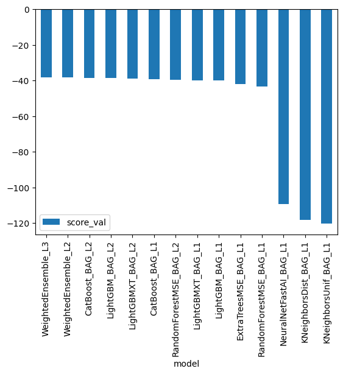

```python
predictor_new_features2.leaderboard(silent=True).plot(kind='bar',x='model',y='score_val')
```

```python
predictions_new_features2 = predictor_new_features2.predict(test)
predictions_new_features2.head()
```

```
0    12.660812
1     6.389424
2     4.843282
3     4.531726
4     4.396791
Name: count, dtype: float32
```

```python
# How many negative values do we have?
print('Number of Negative values in Prediction:',predictions_new_features2[predictions_new_features2<0].count())
```

```
Number of Negative values in Prediction: 26
```

```python
# Remember to set all negative values to zero
predictions_new_features2[predictions_new_features2<0]=0
print('Number of Negative values in Prediction:',predictions_new_features2[predictions_new_features2<0].count())
```

```
Number of Negative values in Prediction: 0
```

```python
submission_new_features2 = pd.read_csv('sampleSubmission.csv',parse_dates=['datetime'])
submission_new_features2.head()
```

|  | datetime | count |
| --- | --- | --- |
| 0 | 2011-01-20 00:00:00 | 0 |
| 1 | 2011-01-20 01:00:00 | 0 |
| 2 | 2011-01-20 02:00:00 | 0 |
| 3 | 2011-01-20 03:00:00 | 0 |
| 4 | 2011-01-20 04:00:00 | 0 |

```python
# Same submitting predictions
submission_new_features2["count"] = predictions_new_features2
submission_new_features2.to_csv("submission_new_features2.csv", index=False)
```

```python
!kaggle competitions submit -c bike-sharing-demand -f submission_new_features2.csv -m "new features2"
```

```python
!kaggle competitions submissions -c bike-sharing-demand | tail -n +1 | head -n 6
```

#### New Score of `0.4914`

## Step 6: Hyper parameter optimization

- There are many options for hyper parameter optimization.
- Options are to change the AutoGluon higher level parameters or the individual model hyperparameters.
- The hyperparameters of the models themselves that are in AutoGluon. Those need the `hyperparameter` and `hyperparameter_tune_kwargs` arguments.

```python
hyperparameters={'RF':{
                     'n_estimators':100,
                     'max_depth':10,
                     'criterion':'squared_error'
                        },
                 'CAT':{
                     'iterations':100,
                     'learning_rate':0.01
                 }
                }
hyperparamters_kwargs={'num_trails':10,
                       'searcher':'random',
                       'scheduler' : 'local'
                      }
```

```python
predictor_new_hpo = TabularPredictor(label='count',eval_metric='root_mean_squared_error').\
                    fit(train_data=train,hyperparameters=hyperparameters,
                        hyperparameter_tune_kwargs=hyperparamters_kwargs,
                        presets='best_quality',
                        time_limit=1800)
```

[output not shown]

[output cut: 251 more lines]

```
Fitted model: CatBoost_BAG_L2/T17 ...
	-86.34	 = Validation score   (-root_mean_squared_error)
	27.75s	 = Training   runtime
	0.0s	 = Validation runtime
Fitted model: CatBoost_BAG_L2/T18 ...
	-85.8245	 = Validation score   (-root_mean_squared_error)
	27.51s	 = Training   runtime
	0.0s	 = Validation runtime
Fitting model: WeightedEnsemble_L3 ... Training model for up to 360.0s of the 578.25s of remaining time.
	Ensemble Weights: {'RandomForest_BAG_L2': 0.947, 'RandomForest_BAG_L1': 0.053}
	-45.6444	 = Validation score   (-root_mean_squared_error)
	0.04s	 = Training   runtime
	0.0s	 = Validation runtime
AutoGluon training complete, total runtime = 931.08s ... Best model: "WeightedEnsemble_L3"
TabularPredictor saved. To load, use: predictor = TabularPredictor.load("AutogluonModels/ag-20240427_091452")
```

```python
predictor_new_hpo.fit_summary()
```

```
*** Summary of fit() ***
Estimated performance of each model:
                  model   score_val              eval_metric  pred_time_val    fit_time  pred_time_val_marginal  fit_time_marginal  stack_level  can_infer  fit_order
0   WeightedEnsemble_L3  -45.644442  root_mean_squared_error       0.006036  455.567820                0.001128           0.041691            3       True         46
1   RandomForest_BAG_L2  -45.654696  root_mean_squared_error       0.004907  455.526130                0.000204          17.931294            2       True         27
2   RandomForest_BAG_L1  -48.874364  root_mean_squared_error       0.000178    2.412204                0.000178           2.412204            1       True          1
3   WeightedEnsemble_L2  -48.874364  root_mean_squared_error       0.001239    2.465253                0.001061           0.053050            2       True         26
4    CatBoost_BAG_L2/T9  -85.403002  root_mean_squared_error       0.004844  474.125308                0.000141          36.530473            2       True         36
5   CatBoost_BAG_L2/T14  -85.453843  root_mean_squared_error       0.004860  465.924621                0.000158          28.329786            2       True         41
6    CatBoost_BAG_L2/T5  -85.483012  root_mean_squared_error       0.004814  474.191492                0.000112          36.596656            2       True         32
7    CatBoost_BAG_L2/T4  -85.615256  root_mean_squared_error       0.004878  473.616259                0.000175          36.021424            2       True         31
8    CatBoost_BAG_L2/T8  -85.662745  root_mean_squared_error       0.004827  465.056849                0.000125          27.462014            2       True         35
9   CatBoost_BAG_L2/T18  -85.824505  root_mean_squared_error       0.004849  465.105103                0.000146          27.510268            2       True         45
10  CatBoost_BAG_L2/T11  -85.993542  root_mean_squared_error       0.004845  460.788054                0.000142          23.193218            2       True         38
11   CatBoost_BAG_L2/T1  -86.194657  root_mean_squared_error       0.004847  460.304488                0.000144          22.709653            2       True         28
```

[output cut: 45 more lines]

[output not shown]

[output cut: 507 more lines]

```
 31       True         22
 32       True         19
 33       True         12
 34       True         20
 35       True          2
 36       True         13
 37       True         18
 38       True         11
 39       True          7
 40       True         14
 41       True          3
 42       True         17
 43       True          4
 44       True         16
 45       True          8  }
```

[figure not shown]

```python
predictor_new_features2.leaderboard(silent=True).plot(kind='bar',x='model',y='score_val')
```

```python
predictions_new_hpo = predictor_new_hpo.predict(test)
predictions_new_hpo.head()
```

```
0    9.343613
1    5.500477
2    3.103681
3    2.112806
4    1.954347
Name: count, dtype: float32
```

```python
# How many negative values do we have?
print('Number of Negative values in Prediction:',predictions_new_hpo[predictions_new_hpo<0].count())
```

```
Number of Negative values in Prediction: 0
```

```python
# Remember to set all negative values to zero
predictions_new_hpo[predictions_new_hpo<0]=0
print('Number of Negative values in Prediction:',predictions_new_hpo[predictions_new_hpo<0].count())
```

```
Number of Negative values in Prediction: 0
```

```python
submission_new_hpo = pd.read_csv('sampleSubmission.csv',parse_dates=['datetime'])
submission_new_hpo.head()
```

|  | datetime | count |
| --- | --- | --- |
| 0 | 2011-01-20 00:00:00 | 0 |
| 1 | 2011-01-20 01:00:00 | 0 |
| 2 | 2011-01-20 02:00:00 | 0 |
| 3 | 2011-01-20 03:00:00 | 0 |
| 4 | 2011-01-20 04:00:00 | 0 |

```python
# Same submitting predictions
submission_new_hpo["count"] = predictions_new_hpo
submission_new_hpo.to_csv("submission_new_hpo.csv", index=False)
```

```python
!kaggle competitions submit -c bike-sharing-demand -f submission_new_hpo.csv -m "new features with hyperparameters"
```

```python
!kaggle competitions submissions -c bike-sharing-demand | tail -n +1 | head -n 6
```